# Comparing Collaborative Filtering Models

#### Part 6 of the MovieLens Project series

##### Previous articles

- Exploratory Data Analysis of MovieLens Dataset
- Baseline Models for Collaborative Filtering
- Recommending Movies with Similarity-Based Collaborative Filtering
- Recommending Movies with Alternating Least Squares
- Recommending Movies with Stochastic Gradient Descent

This is the sixth post of a project on collaborative filtering based on the MovieLens 100K dataset. The remainder of this post is straight out of a Jupyter Notebook file you can download here. You can also see it [here](https://github.com/benlindsay/movielens-analysis/blob/master/06_Model-Comparisons.ipynb) on GitHub.

Now that I've implemented 3 main classes of collaborative filtering methods (similarity-based, alternating least squares (ALS), and stochastic gradient descent (SGD)), it's time to see how they stack up to each other.

To compare models, I'll use 2 different metrics: mean absolute error (MAE) and normalized discounted cumulative gain (NDCG). MAE measures about how many stars off all the predictions are on average. This is useful information, but in most recommendation situations, the user will only see a few of the top recommendations given to them. The NDCG score tells us how "good" the top few recommendations are, with decreasing weight given the farther you go down the list.

Usually, NDCG will be reported for a certain number of recommendations. If we just care about the first 3 recommendations, we would computer NDCG@3. If there were no movies that the user would have rated more highly than these 3, then NDCG@3 is 1.0. Lower values mean other movies would have gotten higher ratings.

If you're interested, the math looks like this:

Given a vector $\mathbf{r}$ of $k$ recommendations from most to least recommended, discounted cumulative gain (DCG) is given by:

$$DCG@k = \sum_{i=1}^k \frac{r_i}{\log_2(i+1)}$$

Normalized DCG (NDCG) is just DCG divided by the maximum possible DCG:

$$ NDCG@k = \frac{DCG@k}{\max_{\mathbf{r}} DCG@k}$$

Expand Code

Expand Code

# 2. Load the Data

Let's load and examine the ratings data. If you're following along (i.e. actually running these notebooks) you'll need to make sure to run the first one to download the data before running this one.

Expand Code

```
First 5:
```

|  | userId | movieId | rating | timestamp |
| --- | --- | --- | --- | --- |
| 214 | 259 | 255 | 4 | 1997-09-19 23:05:10 |
| 83965 | 259 | 286 | 4 | 1997-09-19 23:05:27 |
| 43027 | 259 | 298 | 4 | 1997-09-19 23:05:54 |
| 21396 | 259 | 185 | 4 | 1997-09-19 23:06:21 |
| 82655 | 259 | 173 | 4 | 1997-09-19 23:07:23 |

```
Last 5:
```

|  | userId | movieId | rating | timestamp |
| --- | --- | --- | --- | --- |
| 46773 | 729 | 689 | 4 | 1998-04-22 19:10:38 |
| 73008 | 729 | 313 | 3 | 1998-04-22 19:10:38 |
| 46574 | 729 | 328 | 3 | 1998-04-22 19:10:38 |
| 64312 | 729 | 748 | 4 | 1998-04-22 19:10:38 |
| 79208 | 729 | 272 | 4 | 1998-04-22 19:10:38 |

Expand Code

Expand Code

```
Fold 0:
  Train: between 13 and 491 movies per user
  Test:  between 7 and 246 movies per user
Fold 1:
  Train: between 13 and 491 movies per user
  Test:  between 7 and 246 movies per user
Fold 2:
  Train: between 14 and 492 movies per user
  Test:  between 6 and 245 movies per user
```

Expand Code

Expand Code

# 3. Choose the best user-based model

Let's use cross-validation to examine MAE and NDCG@3 on out-of-sample data and choose the "best" user-based model.

Expand Code

```
k=1, i_fold=0: MAE=0.8335820137299328, NDCG=0.8419218314194908
k=2, i_fold=0: MAE=0.8055319020030114, NDCG=0.8488402325053938
k=5, i_fold=0: MAE=0.7898301104752179, NDCG=0.8568816660263787
k=10, i_fold=0: MAE=0.7844811512641147, NDCG=0.866351545900177
k=20, i_fold=0: MAE=0.7825949168981733, NDCG=0.8663123680140652
k=50, i_fold=0: MAE=0.7823864170624978, NDCG=0.86451390079912
k=100, i_fold=0: MAE=0.7837336683942548, NDCG=0.864783101784657
k=1, i_fold=1: MAE=0.8103195965310307, NDCG=0.8342529646792158
k=2, i_fold=1: MAE=0.7771523904087133, NDCG=0.8445940280960973
k=5, i_fold=1: MAE=0.7541189079102684, NDCG=0.8544306736447582
k=10, i_fold=1: MAE=0.7472360724615519, NDCG=0.8587829551463168
k=20, i_fold=1: MAE=0.744198914317921, NDCG=0.8616782748602941
k=50, i_fold=1: MAE=0.7440653472763141, NDCG=0.8672427206403276
k=100, i_fold=1: MAE=0.7457825084494136, NDCG=0.8646034532713005
k=1, i_fold=2: MAE=0.8591514716745691, NDCG=0.8349623209950944
k=2, i_fold=2: MAE=0.8341265278764367, NDCG=0.8457560801890412
k=5, i_fold=2: MAE=0.8179387558067737, NDCG=0.85340710020124
k=10, i_fold=2: MAE=0.8132244297036613, NDCG=0.8603510473151312
k=20, i_fold=2: MAE=0.8109264482099519, NDCG=0.8639371740798584
k=50, i_fold=2: MAE=0.8108590433573192, NDCG=0.862968089610793
k=100, i_fold=2: MAE=0.8125660602709356, NDCG=0.8604898319974263
```

Expand Code

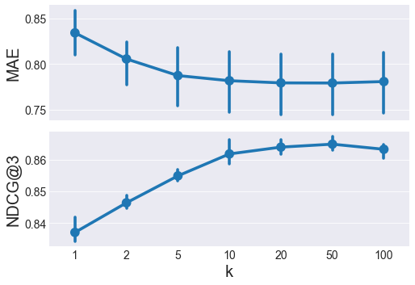

NDCG@3 peaks at $k=50$, and MAE is pretty similar between $k=20$ to $100$, so $k=50$ is the winner.

```python
baseline_algo = DampedUserMovieBaselineModel(damping_factor=10)
best_user_model = KNNRecommender(mode='user', k=50, baseline_algo=baseline_algo)
```

# 4. Choose the best item-based model

Let's use cross-validation to examine MAE and NDCG@3 on out-of-sample data and choose the "best" item-based model.

Expand Code

```
i_fold=0: k=1, k=2, k=5, k=10, k=20, k=50, k=100,
i_fold=1: k=1, k=2, k=5, k=10, k=20, k=50, k=100,
i_fold=2: k=1, k=2, k=5, k=10, k=20, k=50, k=100,
```

Expand Code

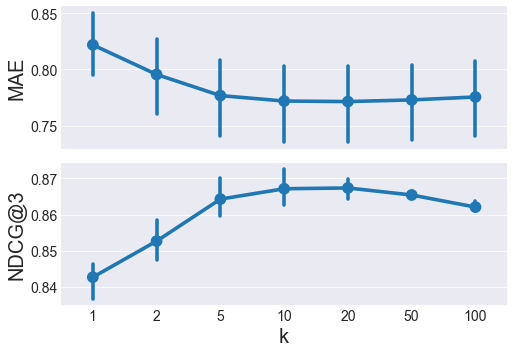

Here, $k=10$ and $k=20$ have similar MAE and NDCG@3, we'll favor higher $k$ in nearest neigbor methods because higher $k$ is less prone to overfitting. $k=20$ is the winner of the item-based models.

```python
baseline_algo = DampedUserMovieBaselineModel(damping_factor=10)
best_item_model = KNNRecommender(mode='item', k=20, baseline_algo=baseline_algo)
```

# 5. Choose the best ALS model

Let's use cross-validation to examine MAE and NDCG@3 on out-of-sample data and choose the "best" ALS model.

Expand Code

```
i_fold=0, k=5: i_epoch=0, 1, 2, 3, 4, 5, 6, 7, 8, 9, 10, 11, 12, 13, 14,
i_fold=0, k=10: i_epoch=0, 1, 2, 3, 4, 5, 6, 7, 8, 9, 10, 11, 12, 13, 14,
i_fold=0, k=50: i_epoch=0, 1, 2, 3, 4, 5, 6, 7, 8, 9, 10, 11, 12, 13, 14,
i_fold=1, k=5: i_epoch=0, 1, 2, 3, 4, 5, 6, 7, 8, 9, 10, 11, 12, 13, 14,
i_fold=1, k=10: i_epoch=0, 1, 2, 3, 4, 5, 6, 7, 8, 9, 10, 11, 12, 13, 14,
i_fold=1, k=50: i_epoch=0, 1, 2, 3, 4, 5, 6, 7, 8, 9, 10, 11, 12, 13, 14,
i_fold=2, k=5: i_epoch=0, 1, 2, 3, 4, 5, 6, 7, 8, 9, 10, 11, 12, 13, 14,
i_fold=2, k=10: i_epoch=0, 1, 2, 3, 4, 5, 6, 7, 8, 9, 10, 11, 12, 13, 14,
i_fold=2, k=50: i_epoch=0, 1, 2, 3, 4, 5, 6, 7, 8, 9, 10, 11, 12, 13, 14,
```

Expand Code

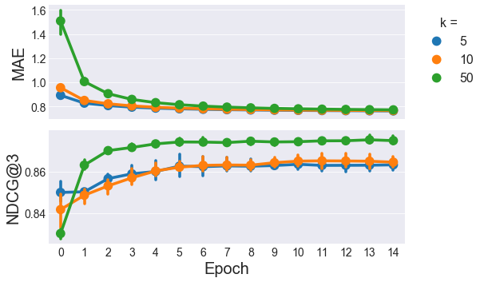

Expand Code

```
i_fold=0, k=20.0: lmbda=0.05
i_fold=0, k=20.0: lmbda=0.1
i_fold=0, k=20.0: lmbda=0.2
i_fold=0, k=50.0: lmbda=0.05
i_fold=0, k=50.0: lmbda=0.1
i_fold=0, k=50.0: lmbda=0.2
i_fold=0, k=100.0: lmbda=0.05
i_fold=0, k=100.0: lmbda=0.1
i_fold=0, k=100.0: lmbda=0.2
i_fold=0, k=200.0: lmbda=0.05
i_fold=0, k=200.0: lmbda=0.1
i_fold=0, k=200.0: lmbda=0.2
i_fold=1, k=20.0: lmbda=0.05
i_fold=1, k=20.0: lmbda=0.1
i_fold=1, k=20.0: lmbda=0.2
i_fold=1, k=50.0: lmbda=0.05
i_fold=1, k=50.0: lmbda=0.1
i_fold=1, k=50.0: lmbda=0.2
i_fold=1, k=100.0: lmbda=0.05
i_fold=1, k=100.0: lmbda=0.1
i_fold=1, k=100.0: lmbda=0.2
i_fold=1, k=200.0: lmbda=0.05
i_fold=1, k=200.0: lmbda=0.1
i_fold=1, k=200.0: lmbda=0.2
i_fold=2, k=20.0: lmbda=0.05
i_fold=2, k=20.0: lmbda=0.1
i_fold=2, k=20.0: lmbda=0.2
i_fold=2, k=50.0: lmbda=0.05
i_fold=2, k=50.0: lmbda=0.1
i_fold=2, k=50.0: lmbda=0.2
i_fold=2, k=100.0: lmbda=0.05
i_fold=2, k=100.0: lmbda=0.1
i_fold=2, k=100.0: lmbda=0.2
i_fold=2, k=200.0: lmbda=0.05
i_fold=2, k=200.0: lmbda=0.1
i_fold=2, k=200.0: lmbda=0.2
```

Expand Code

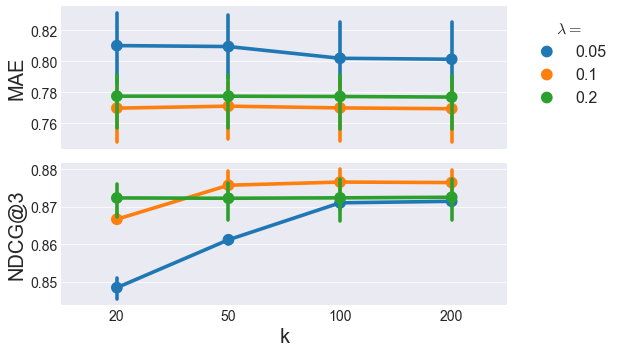

Here, it looks like MAE is pretty flat with respect to the learning rate $\lambda$, but NDCG@3 shows some interesting variations. The highest NDCG@3 comes from $\lambda=0.1$ and $k>=50$. With matrix factorization methods like ALS, we want to favor lower $k$ for better generalizability, so $\lambda=0.1$ and $k=50$ is the winner of the ALS category.

```python
baseline_algo = DampedUserMovieBaselineModel(damping_factor=10)
best_als_model = ALSRecommender(k=50, lmbda=0.1, max_epochs=15, baseline_algo=baseline_algo)
```

# 6. Choose the best SGD model

Let's use cross-validation to examine MAE and NDCG@3 on out-of-sample data and choose the "best" SGD model.

Expand Code

```
i_fold=0, k=5: i_epoch=0, 1, 2, 3, 4, 5, 6, 7, 8, 9, 10, 11, 12, 13, 14,
i_fold=0, k=10: i_epoch=0, 1, 2, 3, 4, 5, 6, 7, 8, 9, 10, 11, 12, 13, 14,
i_fold=0, k=50: i_epoch=0, 1, 2, 3, 4, 5, 6, 7, 8, 9, 10, 11, 12, 13, 14,
i_fold=1, k=5: i_epoch=0, 1, 2, 3, 4, 5, 6, 7, 8, 9, 10, 11, 12, 13, 14,
i_fold=1, k=10: i_epoch=0, 1, 2, 3, 4, 5, 6, 7, 8, 9, 10, 11, 12, 13, 14,
i_fold=1, k=50: i_epoch=0, 1, 2, 3, 4, 5, 6, 7, 8, 9, 10, 11, 12, 13, 14,
i_fold=2, k=5: i_epoch=0, 1, 2, 3, 4, 5, 6, 7, 8, 9, 10, 11, 12, 13, 14,
i_fold=2, k=10: i_epoch=0, 1, 2, 3, 4, 5, 6, 7, 8, 9, 10, 11, 12, 13, 14,
i_fold=2, k=50: i_epoch=0, 1, 2, 3, 4, 5, 6, 7, 8, 9, 10, 11, 12, 13, 14,
```

Expand Code

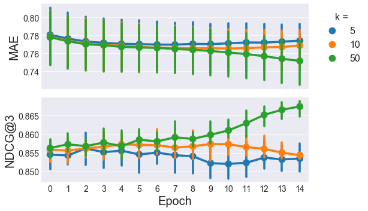

Expand Code

```
i_fold=0, learning_rate=0.001, reg=0.0
i_fold=0, learning_rate=0.001, reg=0.001
i_fold=0, learning_rate=0.001, reg=0.01
i_fold=0, learning_rate=0.01, reg=0.0
i_fold=0, learning_rate=0.01, reg=0.001
i_fold=0, learning_rate=0.01, reg=0.01
i_fold=1, learning_rate=0.001, reg=0.0
i_fold=1, learning_rate=0.001, reg=0.001
i_fold=1, learning_rate=0.001, reg=0.01
i_fold=1, learning_rate=0.01, reg=0.0
i_fold=1, learning_rate=0.01, reg=0.001
i_fold=1, learning_rate=0.01, reg=0.01
i_fold=2, learning_rate=0.001, reg=0.0
i_fold=2, learning_rate=0.001, reg=0.001
i_fold=2, learning_rate=0.001, reg=0.01
i_fold=2, learning_rate=0.01, reg=0.0
i_fold=2, learning_rate=0.01, reg=0.001
i_fold=2, learning_rate=0.01, reg=0.01
```

Expand Code

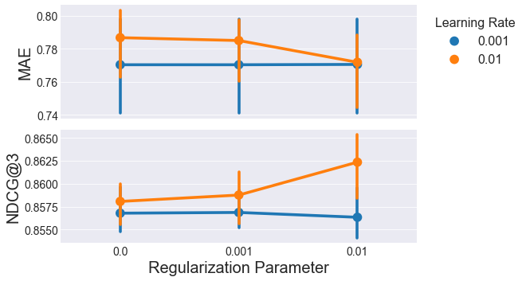

```python
reg = 0.01
best_sgd_model = SGDRecommender(k=50, learning_rate=0.01, max_epochs=30, damping_factor=10,
                                user_reg=reg, item_reg=reg, user_bias_reg=reg, item_bias_reg=reg)
```

# 7. Let's compare the top methods of each category.

Expand Code

```
i_fold=0, model=user
i_fold=1, model=user
i_fold=2, model=user
i_fold=0, model=item
i_fold=1, model=item
i_fold=2, model=item
i_fold=0, model=als
i_fold=1, model=als
i_fold=2, model=als
i_fold=0, model=sgd
i_fold=1, model=sgd
i_fold=2, model=sgd
```

Expand Code

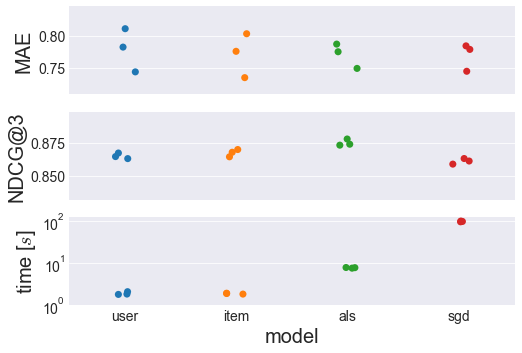

There's a lot of information in the 3 charts above. The charts show 3 different metrics (Mean Absolute Error, Normalized Discounted Cumulative Gain, and time) for the best user-based, item-based, ALS, and SGD models I found. Each metric/model combination has 3 points, representing the values for each of the 3 folds used for cross-validation.

The MAE doesn't seem to change much across the different models, although the variance seems to be slightly smaller for the matrix factorization methods (ALS and SGD) compared to the nearest neighbors methods (user-based and item-based).

The NDCG@3 does seem to vary across the different models though, with the highest score going to the ALS model. NDCG@3 is arguably the more useful metric for a recommender system, so as long as very high speeds aren't important, ALS wins here.

If this ALS model is too slow for a particular application, the item-based method would be the next choice. Both user- and item-based recommenders have similarly fast training speeds, with item-based having a slightly higher NDCG@3 score. The slower execution of the ALS and SGD models are likely related to the number of iterations over for loops required in each iteration.

As they are right now, my user- and item-based models don't need any python for loops during training. ALS has $n_{users} + n_{movies}$ python for loop iterations per epoch, and SGD has $n_{ratings}$ iterations per epoch, which is about an order of magnitude higher. I specify "python" for loops, because the vectorized operations used in user-based, item-based, and ALS models have for loops in c which are much faster than those in python. By optimizing code with something like cython or numba, I could certainly drop the training time for ALS and SGD.

If you want to play with these models interactively, check out [my recommender notebook](https://github.com/benlindsay/movielens-analysis/blob/master/07_Recommender.ipynb). With this notebook, you could choose whichever user you want, show some of their favorite movies, then display the top recommendations given by any of these 4 models.

#### Part 6 of the MovieLens Project series

##### Previous articles

- Exploratory Data Analysis of MovieLens Dataset
- Baseline Models for Collaborative Filtering
- Recommending Movies with Similarity-Based Collaborative Filtering
- Recommending Movies with Alternating Least Squares
- Recommending Movies with Stochastic Gradient Descent

## Comments

[comments powered by Disqus](https://disqus.com)